# Reproducible Research: Peer Assessment 1

This assignment makes use of data from a personal activity monitoring device. This device collects data at 5 minute intervals through out the day. The data consists of two months of data from an anonymous individual collected during the months of October and November, 2012 and include the number of steps taken in 5 minute intervals each day.

## Data

The data for this assignment can be downloaded from the course web site:

- Dataset: [Activity monitoring data](https://d396qusza40orc.cloudfront.net/repdata%2Fdata%2Factivity.zip) [52K]

The variables included in this dataset are:

- **steps**: Number of steps taking in a 5-minute interval (missing values are coded as `NA`)
- **date**: The date on which the measurement was taken in YYYY-MM-DD format
- **interval**: Identifier for the 5-minute interval in which measurement was taken

The dataset is stored in a comma-separated-value (CSV) file and there are a total of 17,568 observations in this dataset.

## Loading and preprocessing the data

```r
library(readr)
activity <- readr::read_csv(unzip("activity.zip", "activity.csv"))
activityData <- transform(activity,day=as.Date(as.Date(date),"%Y%m%d"))
```

## What is mean total number of steps taken per day?

### 2.1. Make a histogram of the total number of steps taken each day

```r
daily <- aggregate(steps~day, data=activityData,FUN=sum)
Sys.setlocale("LC_TIME", "English") ##system language is Russian, need to switch it to English
```

```
## [1] "English_United States.1252"
```

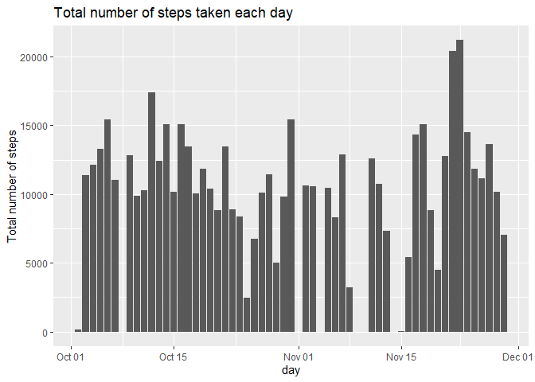

```r
library(ggplot2)
ggplot(daily, aes(day, steps)) +
        geom_histogram(stat="identity") +
        labs(x = "day", y = "Total number of steps", title = "Total number of steps taken each day")
```

### 2.2. Calculate and report the **mean** and **median** total number of steps taken per day

First, let’s calculate **mean** total number of steps taken per day

```r
library(dplyr)
activityData %>% group_by (day) %>%
        summarise(steps = sum(steps, na.rm=TRUE)) %>%
        summarise(steps = mean(steps, na.rm = TRUE))
```

```
## # A tibble: 1 x 1
##   steps
##   <dbl>
## 1 9354.
```

And now let’s calculate **median** total number of steps taken per day

```r
activityData %>% group_by (day) %>%
        summarise(steps = sum(steps, na.rm=TRUE)) %>%
        summarise(steps = median(steps, na.rm = TRUE))
```

```
## # A tibble: 1 x 1
##   steps
##   <dbl>
## 1 10395
```

## What is the average daily activity pattern?

```r
intervalData <- activityData %>% group_by(interval) %>%
        summarise(steps = mean(steps, na.rm = TRUE))
```

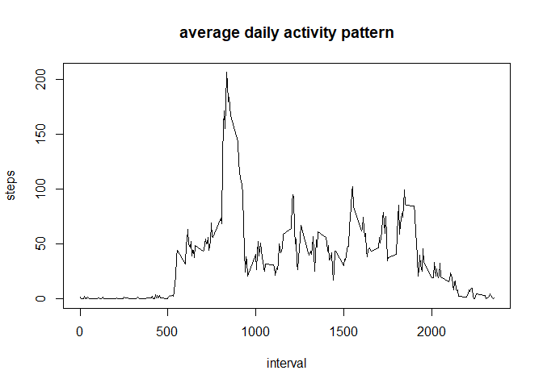

```r
with(intervalData, plot(interval, steps, type = "l", pch=20, main = "average daily activity pattern"))
```

Which 5-minute interval contains the maximum number of steps?

```r
intervalData[order(intervalData$steps, decreasing = TRUE),]
```

```
## # A tibble: 288 x 2
##    interval steps
##       <dbl> <dbl>
##  1      835  206.
##  2      840  196.
##  3      850  183.
##  4      845  180.
##  5      830  177.
##  6      820  171.
##  7      855  167.
##  8      815  158.
##  9      825  155.
## 10      900  143.
## # ... with 278 more rows
```

ANSWER: 835 (8:35)

## Imputing missing values

Calculate and report the total number of missing values

```r
sum(is.na(activityData$steps))
```

```
## [1] 2304
```

Devise a strategy for filling in all of the missing values in the dataset. *strategy: let’s take mean for that 5-minute interval for all other days*

Create a new dataset with the missing data filled in.

```r
imputed.value <- function(steps, interval) {
        inputed <- NA
        if (!is.na(steps))
                inputed <- c(steps)
        else
                inputed <- (intervalData[intervalData$interval==interval, "steps"])
        return(inputed)
}
activityDataNew <- activityData
activityDataNew$steps <- mapply(imputed.value, activityDataNew$steps, activityDataNew$interval)
activityDataNew$steps <- as.numeric(activityDataNew$steps)
```

Make a histogram of the total number of steps taken each day

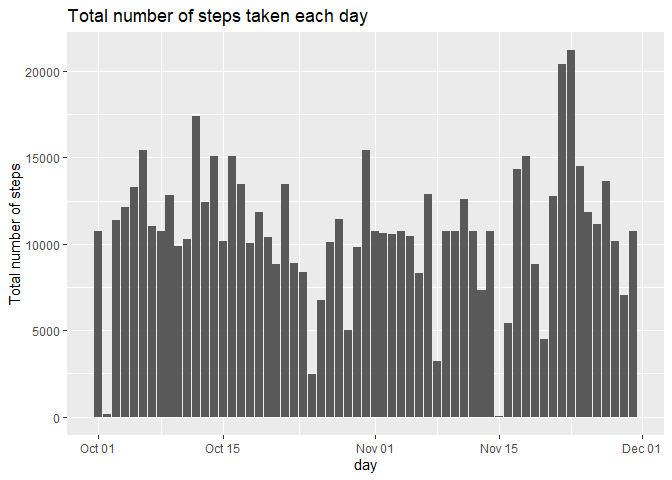

```r
dailyNew <- aggregate(steps~day, data=activityDataNew,FUN=sum)
ggplot(dailyNew, aes(day, steps)) +
        geom_histogram(stat="identity") +
        labs(x = "day", y = "Total number of steps", title = "Total number of steps taken each day")
```

**mean** total number of steps taken per day

```r
activityDataNew %>% group_by (day) %>%
        summarise(steps = sum(steps, na.rm=TRUE)) %>%
        summarise(steps = mean(steps, na.rm = TRUE))
```

```
## # A tibble: 1 x 1
##    steps
##    <dbl>
## 1 10766.
```

**median** total number of steps taken per day

```r
activityDataNew %>% group_by (day) %>%
        summarise(steps = sum(steps, na.rm=TRUE)) %>%
        summarise(steps = median(steps, na.rm = TRUE))
```

```
## # A tibble: 1 x 1
##    steps
##    <dbl>
## 1 10766.
```

**mean** and **median** are higher than the estimates from the first part of the assignment. Imputing missing data is increasing the estimates of the total daily number of steps

## Are there differences in activity patterns between weekdays and weekends?

Create a new factor variable in the dataset with two levels, “weekday” and “weekend”

```r
activityDataNew$week <- weekdays(activityDataNew$date)
activityDataNew$factor <- ifelse(activityDataNew$week == "Saturday" |
                                         activityDataNew$week == "Sunday",
                                 "weekend", "weekday")
```

Make a panel plot

```r
intervalDataWeekend <- activityDataNew %>%
        subset(factor=="weekend") %>%
        group_by(interval) %>%
        summarise(steps = mean(steps, na.rm = TRUE))
intervalDataWeekday <- activityDataNew %>%
        subset(factor=="weekday") %>%
        group_by(interval) %>%
        summarise(steps = mean(steps, na.rm = TRUE))
```

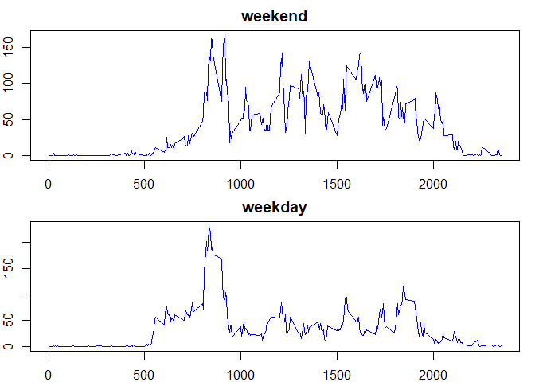

```r
par(mfrow = c(2,1), mar=c(2,2,2,1))
with(intervalDataWeekend, plot(interval, steps, type = "l", pch=20, col="blue", main = "weekend"))
with(intervalDataWeekday, plot(interval, steps, type = "l", pch=20, col="blue", main = "weekday"))
```